# MSC

# Size of stanzas and lines

## Number of lines per stanza

Most stanzas contain an even number of lines (evidence for couplets).

| evenlines | n | prop |
| --- | --- | --- |
| TRUE | 174995 | 0.78 |
| FALSE | 48626 | 0.22 |

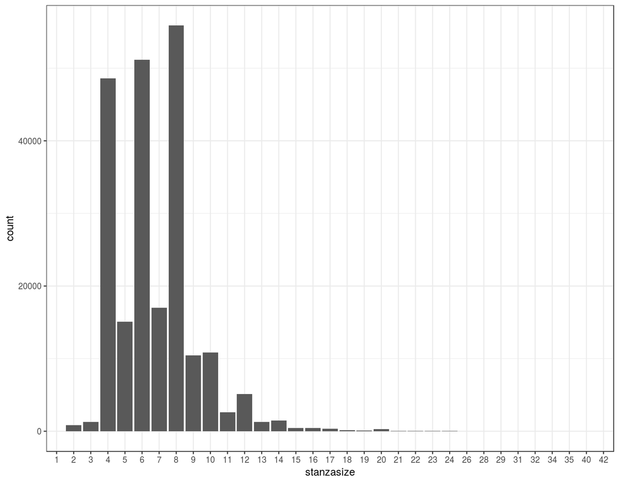

| stanzasize | n | prop |
| --- | --- | --- |
| 8 | 55883 | 0.25 |
| 6 | 51188 | 0.23 |
| 4 | 48610 | 0.22 |
| 7 | 17004 | 0.08 |
| 5 | 15066 | 0.07 |
| 10 | 10823 | 0.05 |
| 9 | 10453 | 0.05 |
| 12 | 5132 | 0.02 |
| 11 | 2606 | 0.01 |
| 14 | 1494 | 0.01 |

## Number of beats per line

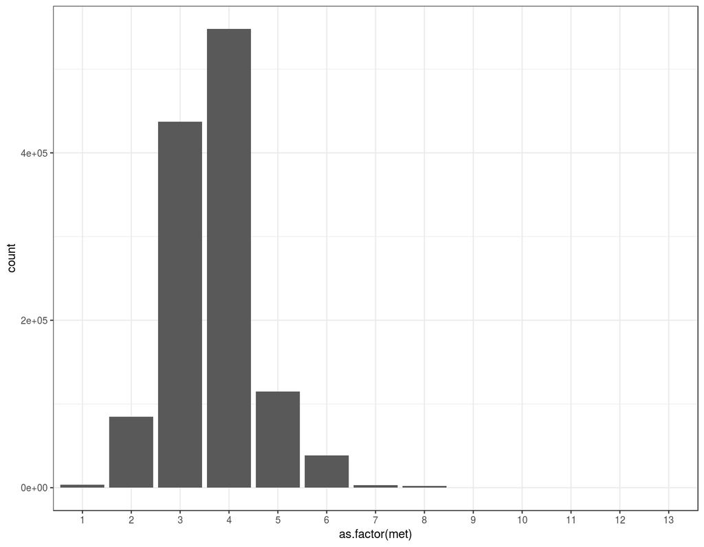

| met | n | prop |
| --- | --- | --- |
| 4 | 548139 | 0.44 |
| 3 | 437220 | 0.35 |
| 5 | 114681 | 0.09 |
| 2 | 84679 | 0.07 |
| 6 | 38541 | 0.03 |
| 1 | 3450 | 0.00 |
| 7 | 3177 | 0.00 |
| 8 | 2265 | 0.00 |
| 9 | 102 | 0.00 |
| 10 | 40 | 0.00 |
| 12 | 24 | 0.00 |
| 11 | 11 | 0.00 |
| 13 | 3 | 0.00 |

# Asymmetries

Check whether couplets have a preference for having long+short lines.

Need some proxy for couplet, since there’s only info on song>stanza>line, but not couplet. As a starting point, take all 4-line stanzas (which account for 22% of the data) and assume they can be subdivided into 2+2. (A further step would be considering evidence from rhyme.)

Most couplets have lines of equal size. Otherwise, the first line is usually the longer one.

| bin_ratio | n | prop |
| --- | --- | --- |
| equal | 62608 | 0.81 |
| long_short | 11563 | 0.15 |
| short_long | 3143 | 0.04 |

Among the couplets with non-equal lines: more than half of the cases have a 4-beat line followed by a 3-beat line. I’m not sure what the `met` field encodes, i.e. whether it actually reflects the musical beats in the line, or the musical beats *with* a syllable associated, or something else. From a musical point of view, it would make sense that couplets with met=4+3 are actually 4+4, but the last beat is empty (i.e. no text).

| couplet_met | n | prop |
| --- | --- | --- |
| 43 | 8452 | 0.57 |
| 45 | 693 | 0.05 |
| 46 | 609 | 0.04 |
| 42 | 605 | 0.04 |
| 64 | 512 | 0.03 |
| 34 | 383 | 0.03 |
| 63 | 369 | 0.03 |
| 32 | 362 | 0.02 |
| 56 | 349 | 0.02 |
| 52 | 296 | 0.02 |

Ratio between the n of beats of second / first line in asymmetric couplets.

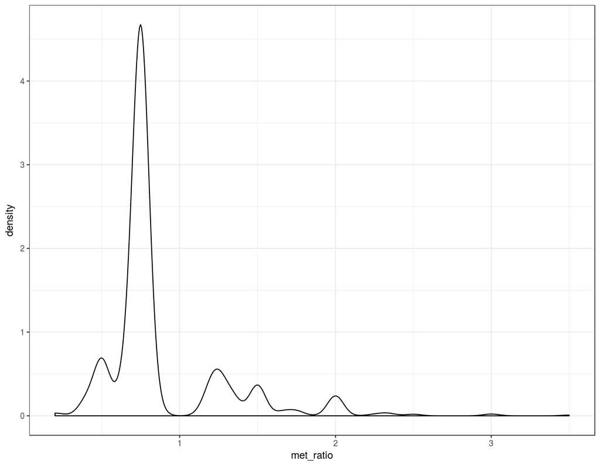